# Linear_mixed_model

RD

2023-08-28

THIS A TEST

## References:

https://www.youtube.com/watch?v=oI1_SV1Rpfc

```r
library(tidyverse)
```

## Step1 : Create the df

```r
df <- data.frame(
  Person = c("Alice", "Bob", "Charlie", "David"),
  Diet = c("A", "A", "B", "B"),
  Before_Diet = c(102, 96, 83, 79),
  After_1_week = c(97, 93, 79, 77),
  After_2_weeks = c(95, 87, 78, 75),
  After_3_weeks = c(93, 85, 74, 72)
)

print(df)
```

```
##    Person Diet Before_Diet After_1_week After_2_weeks After_3_weeks
## 1   Alice    A         102           97            95            93
## 2     Bob    A          96           93            87            85
## 3 Charlie    B          83           79            78            74
## 4   David    B          79           77            75            72
```

## Step2: Plot the data

```r
time_mapping <- c("Before_Diet" = "0", "After_1_week" = "1", "After_2_weeks" = "2", "After_3_weeks" = "3")

df_long <- df %>%
  pivot_longer(cols= Before_Diet:After_3_weeks,
               names_to = "time",
               values_to = "weight") %>%
  mutate(time_clean_weeks = as.numeric(time_mapping[time]))
```

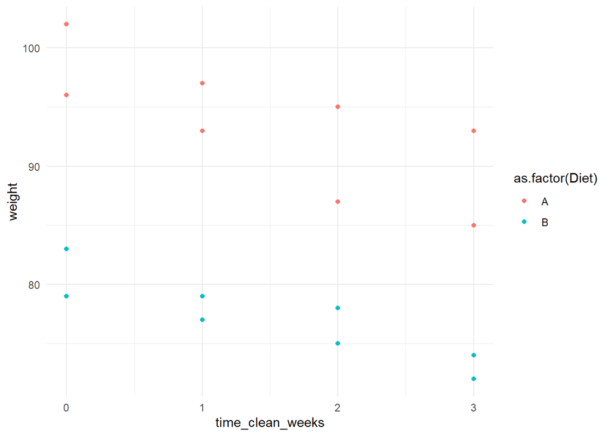

```r
df_long %>%
  ggplot(aes(x = time_clean_weeks,
             y = weight,
             color = as.factor(Diet)))+
  geom_point()+
  theme_minimal()
```

## Use simple linear regression

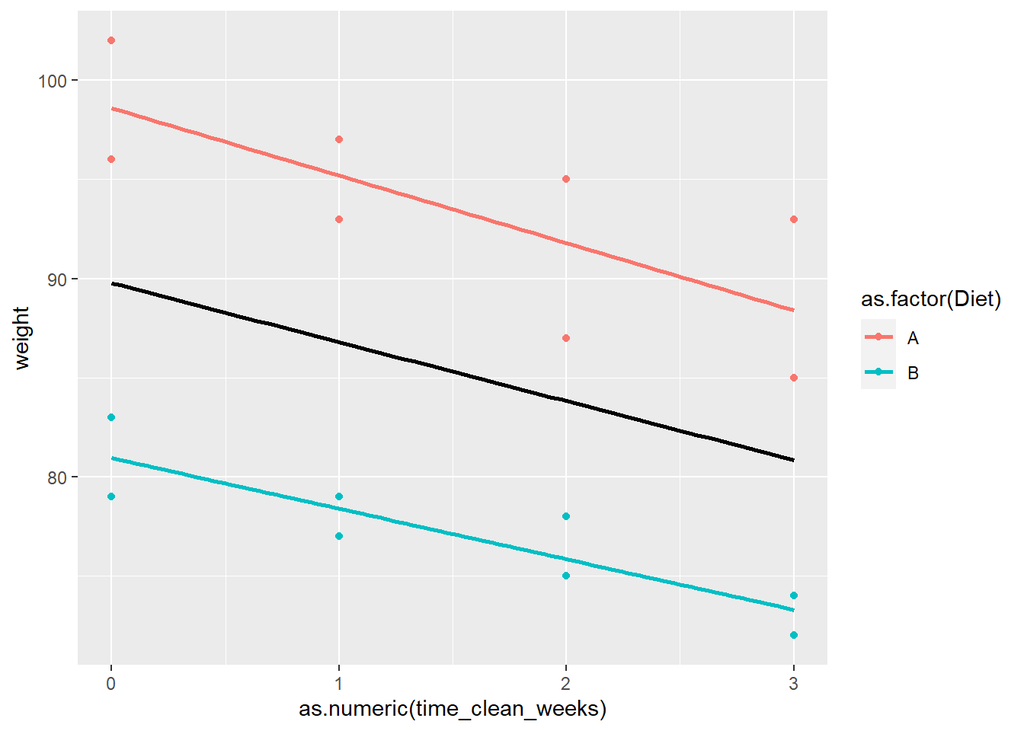

```r
df_long %>%
  ungroup() %>%
  ggplot(aes(x = as.numeric(time_clean_weeks),
             y = weight,
             color = as.factor(Diet)))+
geom_point() +
  geom_smooth(method = "lm", se = FALSE, aes(group = 1), color = "black") +  # General regression
  geom_smooth(method = "lm", se = FALSE, aes(group = Diet))  # Per-group regressions
```

Here, the black line is the overall regression (for all individuals). The colored lines are the per group regressions lines.

```r
overall_regression <- lm(weight ~ time_clean_weeks, data = df_long)
summary(overall_regression)
```

```
##
## Call:
## lm(formula = weight ~ time_clean_weeks, data = df_long)
##
## Residuals:
##     Min      1Q  Median      3Q     Max
## -10.775  -8.056  -1.325   7.219  12.225
##
## Coefficients:
##                  Estimate Std. Error t value Pr(>|t|)
## (Intercept)        89.775      3.851  23.312 1.33e-12 ***
## time_clean_weeks   -2.975      2.058  -1.445     0.17
## ---
## Signif. codes:  0 '***' 0.001 '**' 0.01 '*' 0.05 '.' 0.1 ' ' 1
##
## Residual standard error: 9.206 on 14 degrees of freedom
## Multiple R-squared:  0.1298, Adjusted R-squared:  0.06767
## F-statistic: 2.089 on 1 and 14 DF,  p-value: 0.1704
```

The general intercept is of 89.775 kg (ie the mean weigth for all individuals, at week = 0, so before the diet.)

The slope is of -2.975, meaning that the average weight loss is of approximatively 3kg per week.

The pvalue of the slope is `0.17`, meaning that the slope is not different to 0.

This simple linear regression assumes that all data points are independent, resulting in a high pvalue.

Because we have repeated measures for a same individual, LMM is more appropriate to use.

## Model with random intercepts

For each individual, we estimate the intercept, assuming that all individuals have the same slope.

```r
library(lmerTest)
random_intercept_model <- lmer(weight ~ time_clean_weeks+(1|Person),
                               REML = FALSE,
                               data = df_long)

summary(random_intercept_model)
```

```
## Linear mixed model fit by maximum likelihood . t-tests use Satterthwaite's
##   method [lmerModLmerTest]
## Formula: weight ~ time_clean_weeks + (1 | Person)
##    Data: df_long
##
##      AIC      BIC   logLik deviance df.resid
##     78.2     81.3    -35.1     70.2       12
##
## Scaled residuals:
##      Min       1Q   Median       3Q      Max
## -1.59974 -0.76145 -0.02532  0.71385  1.20036
##
## Random effects:
##  Groups   Name        Variance Std.Dev.
##  Person   (Intercept) 72.965   8.542
##  Residual              1.186   1.089
## Number of obs: 16, groups:  Person, 4
##
## Fixed effects:
##                  Estimate Std. Error      df t value Pr(>|t|)
## (Intercept)       89.7750     4.2952  4.0584   20.90 2.76e-05 ***
## time_clean_weeks  -2.9750     0.2436 12.0000  -12.21 3.97e-08 ***
## ---
## Signif. codes:  0 '***' 0.001 '**' 0.01 '*' 0.05 '.' 0.1 ' ' 1
##
## Correlation of Fixed Effects:
##             (Intr)
## tim_cln_wks -0.085
```

`weight ~ time_clean_weeks+(1|Person)` notation means that: - `weeks` is the fixed-effect - `Person` is the random-effect - the left side of the `|` specifies if we want to use random intercept, slope or both. A `1` represents that we want to create a model with random intercept only for the subjects.

`REML = FALSE` is set so that we can compute the likelihood.

Here, the ouputs can be interpreted as follow: - `89.7750` is the value of the overall intercept - `-2.9750` is the value of the overall slope

These estimated are the same as the one that were obtained with simple LM. But now, the pvalue of the slope is < 0.001 (`time_clean_weeks -2.9750 0.2436 12.0000 -12.21 3.97e-08 ***`).

The random effects (ie the person-wise effect) can be obtained with:

```r
ranef(random_intercept_model)
```

```
## $Person
##         (Intercept)
## Alice     11.391193
## Bob        4.917510
## Charlie   -6.784918
## David     -9.523784
##
## with conditional variances for "Person"
```

The interpretation of this is: “Alice as an intercept (ie weight at week 0) `11.391193` kg higher than the overall intercept”. “David as an intercept `9.523784` kg lower that the overall mean.”

We should also allow for a random slope, because we can expect that people might have different slope (ie different rates at which they lose weight).

To add random slopes, we do:

```r
random_slope_model <- lmer(weight ~ time_clean_weeks+(1 + time_clean_weeks |Person),
                               REML = FALSE,
                               data = df_long)

summary(random_slope_model)
```

```
## Linear mixed model fit by maximum likelihood . t-tests use Satterthwaite's
##   method [lmerModLmerTest]
## Formula: weight ~ time_clean_weeks + (1 + time_clean_weeks | Person)
##    Data: df_long
##
##      AIC      BIC   logLik deviance df.resid
##     80.1     84.8    -34.1     68.1       10
##
## Scaled residuals:
##      Min       1Q   Median       3Q      Max
## -1.66980 -0.49134  0.01578  0.59857  1.34248
##
## Random effects:
##  Groups   Name             Variance Std.Dev. Corr
##  Person   (Intercept)      81.8806  9.0488
##           time_clean_weeks  0.1494  0.3865   -0.88
##  Residual                   0.9375  0.9683
## Number of obs: 16, groups:  Person, 4
##
## Fixed effects:
##                  Estimate Std. Error      df t value Pr(>|t|)
## (Intercept)       89.7750     4.5425  4.0000   19.76 3.87e-05 ***
## time_clean_weeks  -2.9750     0.2902  4.0000  -10.25  0.00051 ***
## ---
## Signif. codes:  0 '***' 0.001 '**' 0.01 '*' 0.05 '.' 0.1 ' ' 1
##
## Correlation of Fixed Effects:
##             (Intr)
## tim_cln_wks -0.634
```

We add the variable “weeks” because we want for every person, to have their individual slopes, associated with the variable “week”.

```r
ranef(random_slope_model)
```

```
## $Person
##         (Intercept) time_clean_weeks
## Alice     11.910177       -0.3533448
## Bob        5.428958       -0.3185862
## Charlie   -7.159986        0.2485626
## David    -10.179149        0.4233684
##
## with conditional variances for "Person"
```

Now, for each individual, we have the intercept value, /t to the overall intercept, and the slope, compared to the overall slope.

“Alice has an intercept of 89.775 + 11.910177 kg. Her slope is of -2.975 + (-0.3533448) = -3.328 kg/week.”

Higher values of random intercept are associated with lower values of the slopes. The correlation between the random slopes and intercepts is of `-0.88`, which is logic: individuals with higher initial weight reduce their weight faster than people with lower initial weight.

## Random slope but same intercept

```r
random_slope_same_intercept_model <- lmer(weight ~ time_clean_weeks+(0 + time_clean_weeks |Person),
                               REML = FALSE,
                               data = df_long)

summary(random_slope_same_intercept_model)
```

```
## Linear mixed model fit by maximum likelihood . t-tests use Satterthwaite's
##   method [lmerModLmerTest]
## Formula: weight ~ time_clean_weeks + (0 + time_clean_weeks | Person)
##    Data: df_long
##
##      AIC      BIC   logLik deviance df.resid
##    118.4    121.4    -55.2    110.4       12
##
## Scaled residuals:
##      Min       1Q   Median       3Q      Max
## -1.70521 -0.55968  0.00879  0.61121  1.93468
##
## Random effects:
##  Groups   Name             Variance Std.Dev.
##  Person   time_clean_weeks  9.778   3.127
##  Residual                  39.928   6.319
## Number of obs: 16, groups:  Person, 4
##
## Fixed effects:
##                  Estimate Std. Error     df t value Pr(>|t|)
## (Intercept)        89.775      2.643 12.000  33.962  2.7e-13 ***
## time_clean_weeks   -2.975      2.107  7.500  -1.412    0.198
## ---
## Signif. codes:  0 '***' 0.001 '**' 0.01 '*' 0.05 '.' 0.1 ' ' 1
##
## Correlation of Fixed Effects:
##             (Intr)
## tim_cln_wks -0.538
```

```r
ranef(random_slope_same_intercept_model)
```

```
## $Person
##         time_clean_weeks
## Alice           3.815645
## Bob             1.382480
## Charlie        -2.211968
## David          -2.986157
##
## with conditional variances for "Person"
```

Using a same intercept is not appropriate here, because persons have a different weight before the start of the diet.

But, it can be appropriate if we fit the model to weight changes, because all four persons will then have a same intercept value of 0.

```r
# Calculate the initial weight for each person
df_initial_weight <- df_long %>%
  filter(time_clean_weeks == 0) %>%
  select(Person, initial_weight = weight)

# Join the initial weight back to the original DataFrame
df_long <- df_long %>%
  full_join(df_initial_weight, by = "Person")

# Calculate the weight change compared to the initial weight
df_long <- df_long %>%
  arrange(Person, time_clean_weeks) %>%
  mutate(weight_change = weight - initial_weight)
```

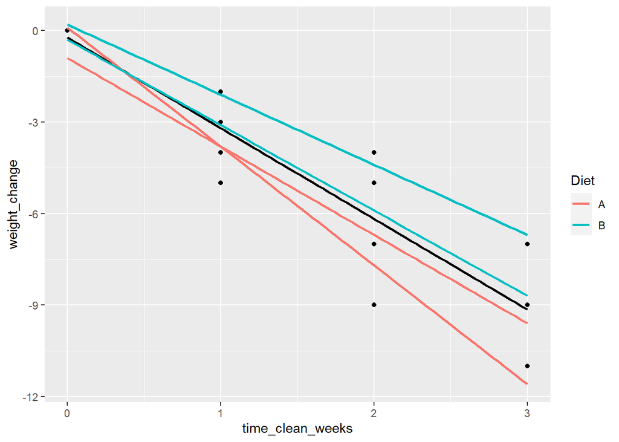

```r
df_long %>%
  ggplot(aes(x = time_clean_weeks,
             y = weight_change))+
  geom_point()+
  geom_smooth(method = "lm", se = FALSE, aes(group = 1), color = "black") +  # General regression
  geom_smooth(method = "lm", se = FALSE, aes(group = Person, color= Diet))  # Per-group regressions
```

## Include the type of diet

Try a model with random intercepts (`1`)

```r
diet_model <- lmer(weight ~ time_clean_weeks+ Diet + (1 |Person),
                               REML = FALSE,
                               data = df_long)

summary(diet_model)
```

```
## Linear mixed model fit by maximum likelihood . t-tests use Satterthwaite's
##   method [lmerModLmerTest]
## Formula: weight ~ time_clean_weeks + Diet + (1 | Person)
##    Data: df_long
##
##      AIC      BIC   logLik deviance df.resid
##     70.3     74.2    -30.2     60.3       11
##
## Scaled residuals:
##      Min       1Q   Median       3Q      Max
## -1.76023 -0.85112  0.06013  0.81347  1.03987
##
## Random effects:
##  Groups   Name        Variance Std.Dev.
##  Person   (Intercept) 5.930    2.435
##  Residual             1.186    1.089
## Number of obs: 16, groups:  Person, 4
##
## Fixed effects:
##                  Estimate Std. Error       df t value Pr(>|t|)
## (Intercept)       97.9625     1.8019   4.3477  54.367 2.51e-07 ***
## time_clean_weeks  -2.9750     0.2436  12.0000 -12.215 3.97e-08 ***
## DietB            -16.3750     2.4953   4.0000  -6.562  0.00279 **
## ---
## Signif. codes:  0 '***' 0.001 '**' 0.01 '*' 0.05 '.' 0.1 ' ' 1
##
## Correlation of Fixed Effects:
##             (Intr) tm_cl_
## tim_cln_wks -0.203
## DietB       -0.692  0.000
```

Here, we assume that both diet have the same slope (of `-2.975` kg/week).

Let’s look at the results per individuals:

```r
ranef(diet_model)
```

```
## $Person
##         (Intercept)
## Alice      3.095180
## Bob       -3.095180
## Charlie    1.309499
## David     -1.309499
##
## with conditional variances for "Person"
```

Alice has an intercept about 3kg bigger than the overall intercept of her category (here Diet A.)

[figure not shown]